# Life Science and Device Intel

**Week of October 12, 2026**Market data through: October 9, 2026Narrative created: October 5, 2026

Weekly review of pharmaceutical, biotech, biologics, and medical-device company performance, changes, earnings activity, and strategy narrative.

## In the News

No strategy narrative is available for this week.

## Notable Changes

Comparison with the final report dated October 5, 2026 (market data through October 2, 2026).

### Sectors

#### Top-three comparison

| Entity | Previous | Current | Change | Current return |
| --- | --- | --- | --- | --- |
| Established Biotech | #1 | #1 | — 0 | +47.5% |
| Emerging Biotech | #2 | #2 | — 0 | +35.0% |
| Big Pharma | #3 | #3 | — 0 | +27.2% |

### Stocks

#### Top-three comparison

| Entity | Previous | Current | Change | Current return |
| --- | --- | --- | --- | --- |
| Moderna (MRNA) | #1 | #1 | — 0 | +738.6% |
| Krystal Biotech (KRYS) | #2 | #2 | — 0 | +82.7% |
| Viatris (VTRS) | #3 | #3 | — 0 | +81.1% |

#### Largest rank changes

| Entity | Previous | Current | Change | Current return |
| --- | --- | --- | --- | --- |
| Corcept Therapeutics (CORT) | #13 | #5 | ↑ 8 | +63.9% |
| Pfizer (PFE) | #29 | #23 | ↑ 6 | +14.1% |
| Argenx (ARGX) | #21 | #29 | ↓ 8 | +3.5% |

### Subcategory movement since the previous report

| Subcategory | Move | Last Report, 12m Ret | Current Report, 12m Ret |
| --- | --- | --- | --- |
| Devices & Diagnostic | +2.6% | -18.7% | -13.9% |
| Big Pharma | +2.3% | +22.5% | +27.2% |
| Established Biotech | +2.1% | +39.3% | +47.5% |
| Emerging Biotech | +0.6% | +30.9% | +35.0% |

### Largest company moves

| Direction | Company | Ticker | Move |
| --- | --- | --- | --- |
| Gain | Moderna | MRNA | +18.4% |
| Gain | Ocular therapeutix | OCUL | +8.3% |
| Gain | Intuitive Surgical | ISRG | +8.2% |
| Decline | Argenx | ARGX | -10.2% |
| Decline | CG Oncology | CGON | -5.3% |
| Decline | BioMarin Pharmaceutical | BMRN | -4.2% |

## Subcategory Performance

| Subcategory | Companies | Market cap | 3m Return | 12m Return | 24m Return |
| --- | --- | --- | --- | --- | --- |
| Devices & Diagnostic | 16 | $888.1B | +1.3% | -13.9% | -13.4% |
| Big Pharma | 12 | $3.6T | +1.0% | +27.2% | +24.8% |
| Established Biotech | 15 | $813.7B | +14.0% | +47.5% | +38.8% |
| Emerging Biotech | 10 | $56.3B | -5.5% | +35.0% | +100.7% |

Subcategory returns use the most recently saved market capitalizations as weights.

## Stock Performance vs. SPY

The same selected stocks appear in every chart. Each line is labeled at the right with its ticker and return for the displayed window.

### Last 6 months

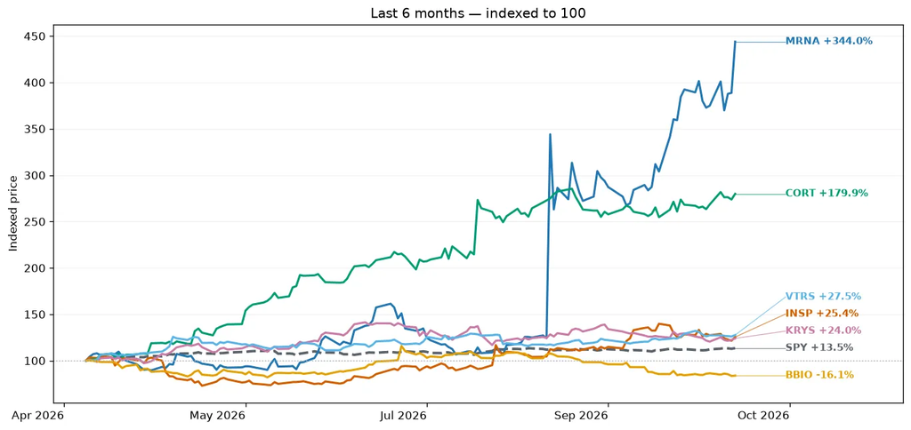

### Last 12 months

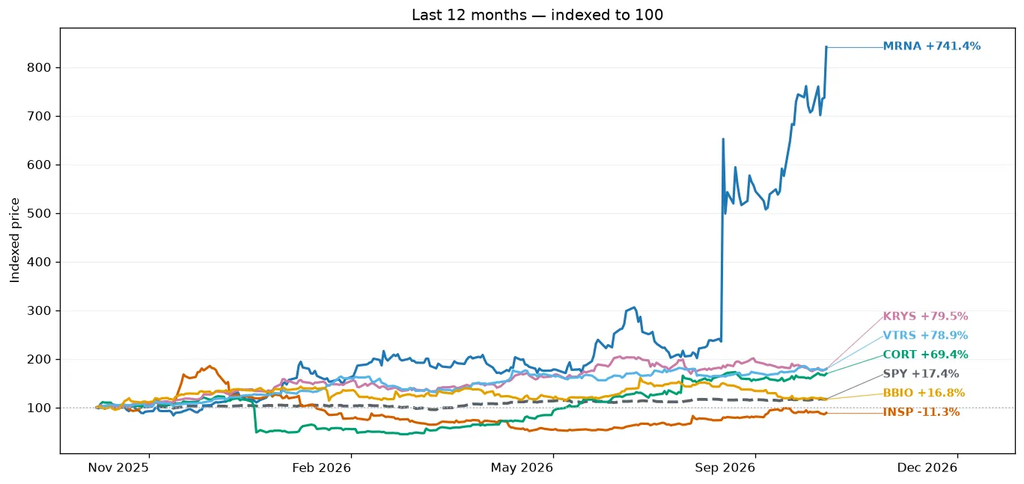

### Last 24 months

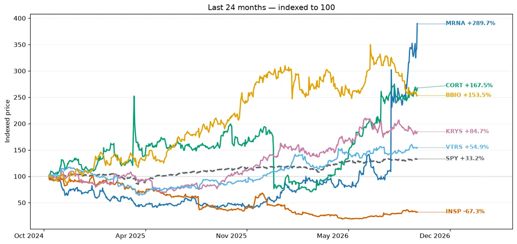

## Current Top Stocks

### Last 3 months

| Rank | Company | Ticker | Market cap | Return |
| --- | --- | --- | --- | --- |
| 1 | Moderna | MRNA | $22.8B | +229.6% |
| 2 | Inspire Medical Systems | INSP | $1.9B | +33.1% |
| 3 | Corcept Therapeutics | CORT | $11.9B | +31.9% |
| 4 | Recursion Pharmaceuticals | RXRX | $1.8B | +22.5% |
| 5 | Becton Dickinson | BDX | $48.2B | +20.9% |

### Last 12 months

| Rank | Company | Ticker | Market cap | Return |
| --- | --- | --- | --- | --- |
| 1 | Moderna | MRNA | $22.8B | +738.6% |
| 2 | Krystal Biotech | KRYS | $9.6B | +82.7% |
| 3 | Viatris | VTRS | $20.6B | +81.1% |
| 4 | Merck | MRK | $316.1B | +69.3% |
| 5 | Corcept Therapeutics | CORT | $11.9B | +63.9% |

### Last 24 months

| Rank | Company | Ticker | Market cap | Return |
| --- | --- | --- | --- | --- |
| 1 | Moderna | MRNA | $22.8B | +286.0% |
| 2 | Corcept Therapeutics | CORT | $11.9B | +166.8% |
| 3 | BridgeBio Pharma | BBIO | $16.1B | +152.3% |
| 4 | Exelixis | EXEL | $14.1B | +128.2% |
| 5 | Krystal Biotech | KRYS | $9.6B | +85.6% |

## Companies by Subcategory

### Devices & DiagnosticLast 3m: +1.3%

| Company | Ticker | Market cap | 3m Return | 12m Return | 24m Return |
| --- | --- | --- | --- | --- | --- |
| Medtronic | MDT | $110.3B | +5.5% | -7.3% | -1.0% |
| Boston Scientific | BSX | $71.1B | -4.6% | -55.2% | -50.9% |
| Stryker | SYK | $128.9B | -15.9% | -23.9% | -22.0% |
| Zimmer Biomet | ZBH | $18.5B | -2.4% | -5.9% | -13.9% |
| Abbott | ABT | $182.5B | +6.0% | -24.9% | -14.2% |
| Becton Dickinson | BDX | $48.2B | +20.9% | -1.5% | -22.3% |
| Edwards LifeSciences | EW | $51.6B | -7.6% | +15.2% | +25.1% |
| Dexcom | DXCM | $32.8B | +12.2% | +29.2% | +21.5% |
| ResMed | RMD | $32.4B | +12.8% | -15.4% | -4.3% |
| Insulet | PODD | $11.6B | -16.1% | -57.0% | -42.0% |
| Globus Medical | GMED | $11.1B | -4.4% | +32.0% | +5.8% |
| Intuitive Surgical | ISRG | $130.1B | +4.2% | -1.3% | -12.5% |
| GE Healthcare | GEHC | $31.7B | +1.6% | -7.4% | -27.8% |
| Transmedics | TMDX | $2.8B | +9.3% | -27.4% | -42.4% |
| STERIS | STE | $22.7B | -0.7% | -9.1% | -5.5% |
| Inspire Medical Systems | INSP | $1.9B | +33.1% | -8.4% | -67.3% |

### Big PharmaLast 3m: +1.0%

| Company | Ticker | Market cap | 3m Return | 12m Return | 24m Return |
| --- | --- | --- | --- | --- | --- |
| Eli Lilly | LLY | $1.0T | -0.8% | +41.5% | +26.5% |
| Novo Nordisk | NVO | $195.8B | -21.9% | -32.1% | -67.8% |
| AbbVie | ABBV | $430.8B | +11.4% | +19.9% | +42.4% |
| Johnson & Johnson | JNJ | $614.4B | +1.7% | +37.1% | +61.9% |
| Pfizer | PFE | $144.8B | +17.0% | +14.1% | -3.0% |
| Merck | MRK | $316.1B | +17.9% | +69.3% | +32.7% |
| Bristol Myers Squibb | BMY | $134.6B | +2.7% | +34.5% | +13.3% |
| Viatris | VTRS | $20.6B | +8.4% | +81.1% | +55.0% |
| AstraZeneca | AZN | $241.3B | -7.2% | -5.8% | +2.9% |
| Novartis | NVS | $291.3B | -6.7% | +10.6% | +23.7% |
| Sanofi | SNY | $103.6B | -7.9% | -16.7% | -27.1% |
| GSK | GSK | $103.2B | -11.9% | +6.8% | +19.8% |

### Established BiotechLast 3m: +14.0%

| Company | Ticker | Market cap | 3m Return | 12m Return | 24m Return |
| --- | --- | --- | --- | --- | --- |
| Vertex | VRTX | $121.3B | +5.1% | +25.1% | +5.9% |
| Regeneron | REGN | $78.3B | +12.3% | +32.2% | -26.5% |
| Amgen | AMGN | $210.5B | +14.2% | +43.0% | +26.3% |
| Gilead | GILD | $167.9B | +16.4% | +29.0% | +78.0% |
| Biogen | BIIB | $30.8B | +13.3% | +54.0% | +19.8% |
| Alnylam | ALNY | $29.3B | -22.1% | -49.5% | -18.2% |
| Sarepta | SRPT | $1.7B | -5.8% | -19.3% | -85.7% |
| Moderna | MRNA | $22.8B | +229.6% | +738.6% | +286.0% |
| Exelixis | EXEL | $14.1B | +5.9% | +56.9% | +128.2% |
| Argenx | ARGX | $52.8B | -6.0% | +3.5% | +53.7% |
| Neurocrine Biosciences | NBIX | $16.9B | -19.6% | +4.3% | +23.3% |
| United Therapeutics | UTHR | $22.0B | +0.4% | +24.8% | +53.3% |
| Incyte | INCY | $24.4B | -3.4% | +34.6% | +70.6% |
| BioMarin Pharmaceutical | BMRN | $11.7B | -7.3% | +4.7% | -22.1% |
| Ionis Pharmaceuticals | IONS | $9.2B | -22.3% | -35.3% | +17.8% |

### Emerging BiotechLast 3m: -5.5%

| Company | Ticker | Market cap | 3m Return | 12m Return | 24m Return |
| --- | --- | --- | --- | --- | --- |
| ADMA Biologics | ADMA | $2.1B | +14.1% | -28.7% | -39.6% |
| Ocular therapeutix | OCUL | $1.9B | -26.1% | -36.0% | -22.9% |
| Novocure | NVCR | $1.9B | -10.6% | +8.1% | -7.4% |
| Corcept Therapeutics | CORT | $11.9B | +31.9% | +63.9% | +166.8% |
| Acadia Pharmaceuticals | ACAD | $4.6B | -24.6% | -1.4% | +32.6% |
| Krystal Biotech | KRYS | $9.6B | -9.3% | +82.7% | +85.6% |
| Avidity Biosciences | RNA | $197.4M | -32.6% | -83.1% | -82.0% |
| Recursion Pharmaceuticals | RXRX | $1.8B | +22.5% | -18.0% | -34.1% |
| CG Oncology | CGON | $6.3B | -15.2% | +47.6% | +76.8% |
| BridgeBio Pharma | BBIO | $16.1B | -23.9% | +17.8% | +152.3% |

## Upcoming Earnings

### Big Pharma

| Company | Ticker | Date | Market cap | 3m Return | 12m Return |
| --- | --- | --- | --- | --- | --- |
| Johnson & Johnson | JNJ | October 13, 2026 | $614.4B | +1.7% | +37.1% |

## Recent Earnings Highlights — 3m Ret

No earnings highlights fall within this report's window.

## Company Overviews

### Medtronic (MDT)

*Devices & Diagnostic · $110.3B · 3m +5.5% · 12m -7.3% · 24m -1.0%*

[Google Finance](https://www.google.com/finance/quote/MDT:NYSE?tab=earnings&hl=en)

Large medical device company with broad portfolio across cardiovascular, neuroscience, surgical, and diabetes care.

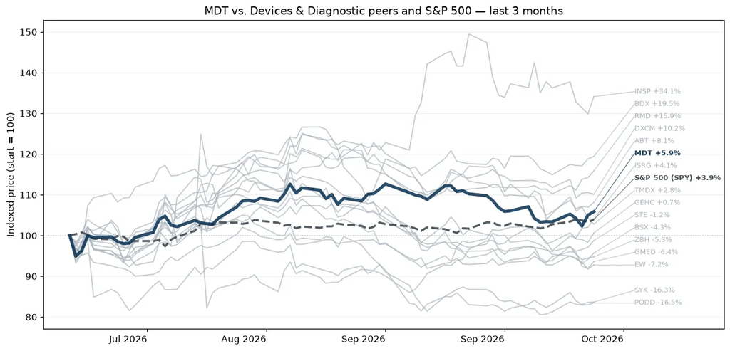

One of the largest medical-device companies, Medtronic develops and manufactures therapeutic medical devices for chronic diseases. Its portfolio includes pacemakers, defibrillators, transcatheter heart valves, stents, spinal fixation devices, neurovascular products, advanced energy, ablation laser therapy, and surgical tools. The company primarily markets its products to healthcare institutions and physicians in the United States, Western Europe, and Japan. Foreign sales account for roughly 50% of the company's total sales.

### Boston Scientific (BSX)

*Devices & Diagnostic · $71.1B · 3m -4.6% · 12m -55.2% · 24m -50.9%*

[Google Finance](https://www.google.com/finance/quote/BSX:NYSE?tab=earnings&hl=en)

Growth-focused medtech leader specializing in minimally invasive cardiovascular, electrophysiology, endoscopy, and neuromodulation devices.

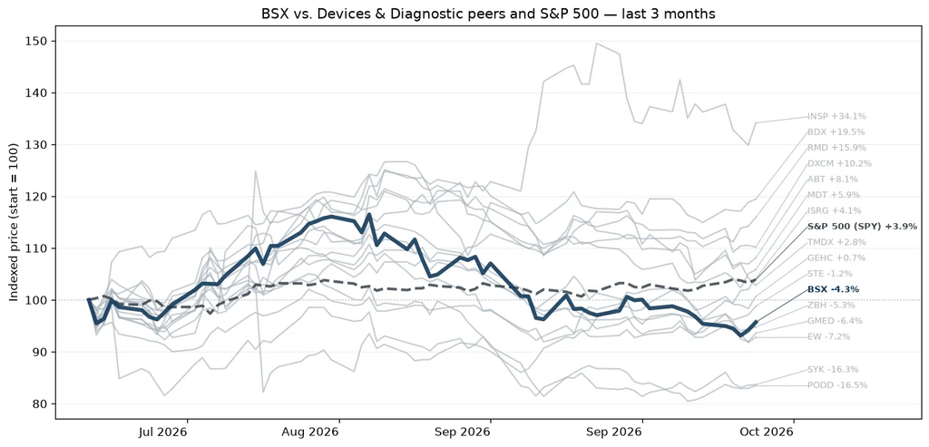

Boston Scientific focuses on less invasive medical devices that are inserted into the human body through small openings or cuts. It manufactures products for use in angioplasty, blood clot filtration, kidney stone management, cardiac rhythm management, catheter-directed ultrasound imaging, upper gastrointestinal tract diagnostics, interventional oncology, neuromodulation for chronic pain, and treatment of incontinence. The firm markets its devices to healthcare professionals and institutions globally. Foreign sales account for roughly 36% of the firm's total sales.

### Stryker (SYK)

*Devices & Diagnostic · $128.9B · 3m -15.9% · 12m -23.9% · 24m -22.0%*

[Google Finance](https://www.google.com/finance/quote/SYK:NYSE?tab=earnings&hl=en)

Premier orthopedic and surgical technology company best known for joint replacements, MedSurg equipment, and Mako robotic assisted surgery systems.

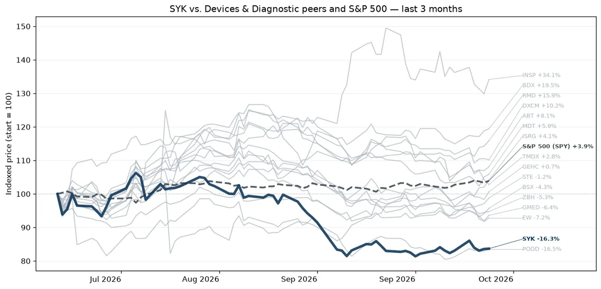

Stryker designs, manufactures, and markets an array of medical equipment, instruments, consumable supplies, and implantable devices. The product portfolio includes hip and knee replacements, extremities, endoscopy systems, operating room equipment, embolic coils, mechanical thrombectomy systems, hospital beds and gurneys, and orthopedic robotics. Stryker remains one of the three largest competitors in reconstructive orthopedic implants and holds the leadership position in operating room equipment. Roughly one-fourth of Stryker's total revenue currently comes from outside the United States.

### Zimmer Biomet (ZBH)

*Devices & Diagnostic · $18.5B · 3m -2.4% · 12m -5.9% · 24m -13.9%*

[Google Finance](https://www.google.com/finance/quote/ZBH:NYSE?tab=earnings&hl=en)

Orthopedic specialist centered on knee, hip, and extremity implants, with robotic surgery offerings for joint reconstruction.

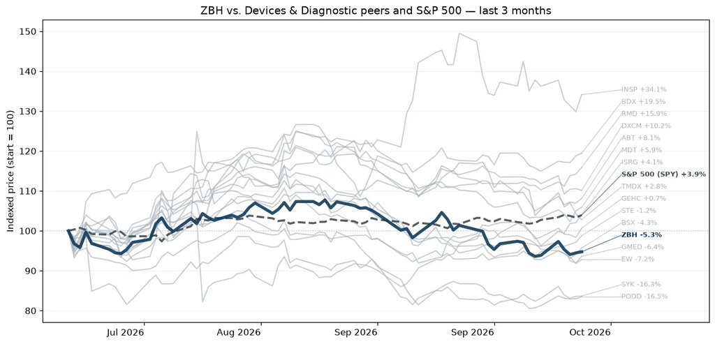

Zimmer Biomet designs, manufactures, and markets orthopedic reconstructive implants as well as supplies and surgical equipment for orthopedic surgery. With the acquisitions of Centerpulse in 2003 and Biomet in 2015, Zimmer holds the leading share of the reconstructive market in the United States, Europe, and Japan. Roughly two-thirds of total revenue is derived from sales of large joints; another fourth comes from extremities, trauma, sports medicine, and related surgical products. The firm spun out its dental and spine businesses in 2022.

### Abbott (ABT)

*Devices & Diagnostic · $182.5B · 3m +6.0% · 12m -24.9% · 24m -14.2%*

[Google Finance](https://www.google.com/finance/quote/ABT:NYSE?tab=earnings&hl=en)

Diversified healthcare company spanning diagnostics, medical devices, nutrition products, and established pharmaceuticals.

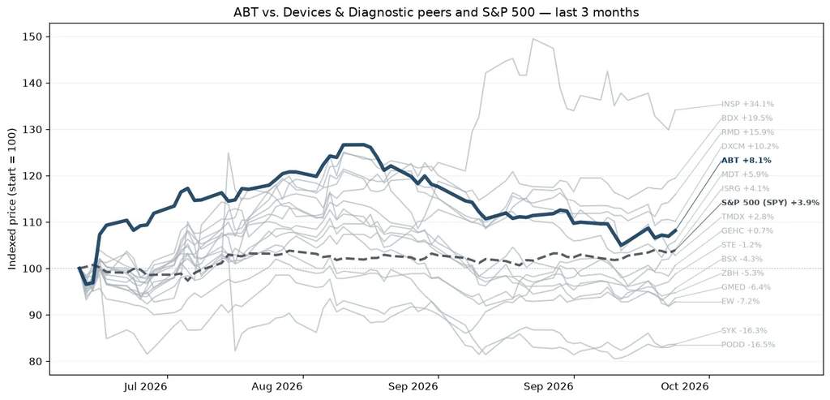

Abbott manufactures and markets cardiovascular and diabetes devices, adult and pediatric nutritional products, diagnostic equipment and testing kits, and branded generic drugs. Products include pacemakers, implantable cardioverter defibrillators, neuromodulation devices, coronary stents, catheters, infant formula, nutritional liquids for adults, continuous glucose monitors, and immunoassays and point-of-care diagnostic equipment. Abbott derives roughly 60% of sales outside the United States.

### Becton Dickinson (BDX)

*Devices & Diagnostic · $48.2B · 3m +20.9% · 12m -1.5% · 24m -22.3%*

[Google Finance](https://www.google.com/finance/quote/BDX:NYSE?tab=earnings&hl=en)

leading medical product and component company.

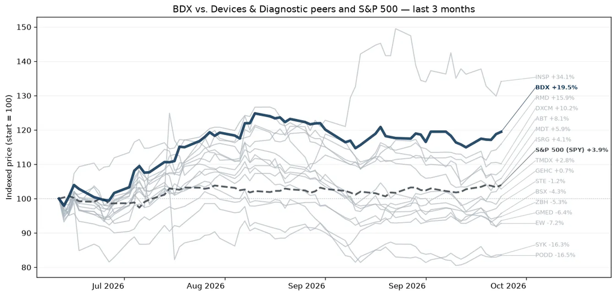

Following the separation of the life science segment, Becton Dickinson operates in four business units. Medical essentials (35% of total sales) includes the legacy medical surgical unit, which sells catheters, syringes, and infection prevention products. Connected care (24%) core products include the Alaris infusion pump, Pyxis dispensing system, and pharmacy automation platforms. Biopharma systems (13%) produces prefillable syringes and autoinjectors. Interventional (29%) is composed of the surgery, peripheral vascular, and urology segments. More than 60% of revenue comes from the United States.

### Edwards LifeSciences (EW)

*Devices & Diagnostic · $51.6B · 3m -7.6% · 12m +15.2% · 24m +25.1%*

[Google Finance](https://www.google.com/finance/quote/EW:NYSE?tab=earnings&hl=en)

Cardiovascular company focused on structural heart therapies, particularly transcatheter and surgical heart valve tech.

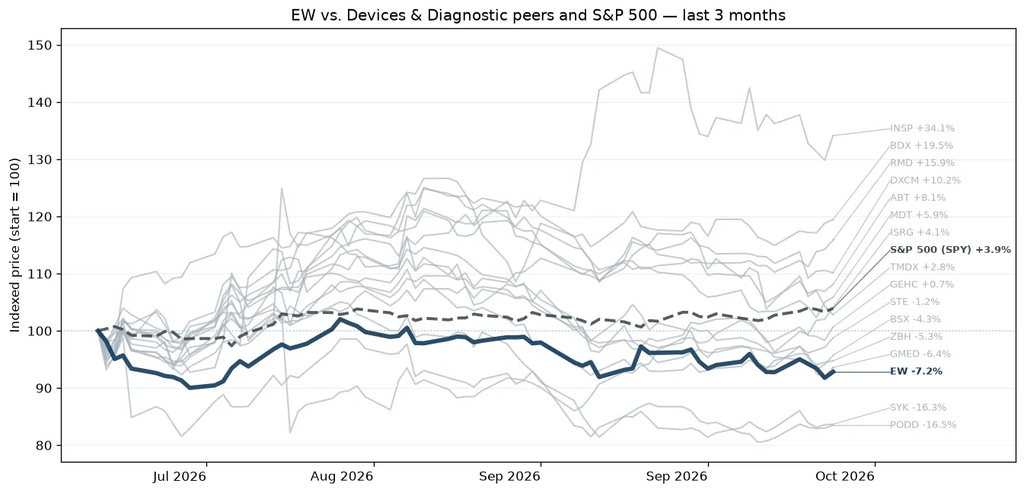

Spun off from Baxter International in 2000, Edwards Lifesciences designs, manufactures, and markets a range of medical devices and equipment for advanced stages of structural heart disease. It has established itself as a leader across key products, including surgical tissue heart valves, transcatheter aortic valves, and transcatheter mitral and tricuspid valve technologies. The firm derives about 60% of its total sales from outside the US.

### Dexcom (DXCM)

*Devices & Diagnostic · $32.8B · 3m +12.2% · 12m +29.2% · 24m +21.5%*

[Google Finance](https://www.google.com/finance/quote/DXCM:NASDAQ?tab=earnings&hl=en)

Leading independent continuous glucose monitoring company.

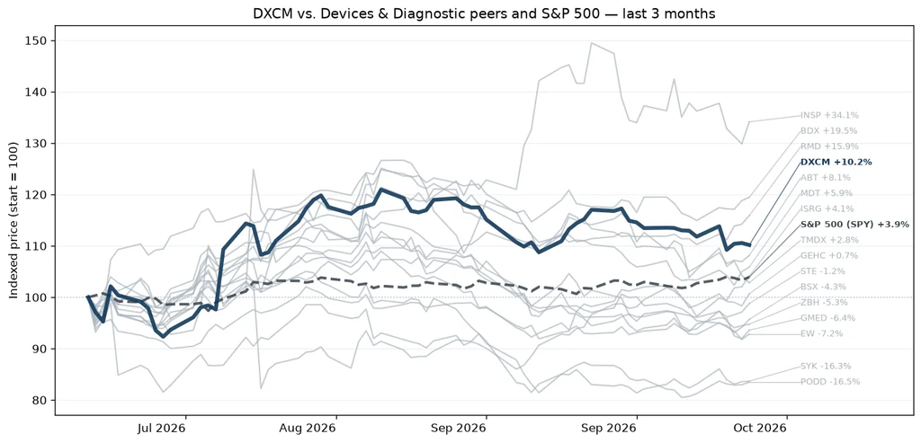

DexCom designs and commercializes continuous glucose monitoring systems for diabetic patients. CGM systems serve as an alternative to the traditional blood glucose meter process, and the company is evolving its CGM systems to provide integration with insulin pumps from Insulet and Tandem for automatic insulin delivery. DexCom's CGMs are available through medical equipment distributors as well as retail pharmacies.

### ResMed (RMD)

*Devices & Diagnostic · $32.4B · 3m +12.8% · 12m -15.4% · 24m -4.3%*

[Google Finance](https://www.google.com/finance/quote/RMD:NYSE?tab=earnings&hl=en)

Sleep and respiratory care known for CPAP devices, masks, and connected software for sleep apnea and respiratory disorders.

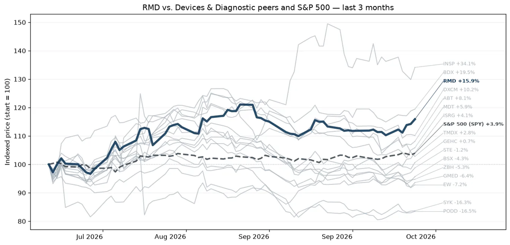

ResMed is one of the largest respiratory care device companies globally, primarily developing and supplying flow generators, masks, and accessories for the treatment of sleep apnea. Increasing diagnosis of sleep apnea combined with aging populations and increasing prevalence of obesity is resulting in a structurally growing market. The company earns roughly two-thirds of its revenue in the Americas and the balance across other regions dominated by Europe, Japan, and Australia. Recent developments and acquisitions have focused on digital health as ResMed is aiming to differentiate itself through the provision of clinical data for use by the patient, medical care advisor, and payer in the out-of-hospital setting.

### Insulet (PODD)

*Devices & Diagnostic · $11.6B · 3m -16.1% · 12m -57.0% · 24m -42.0%*

[Google Finance](https://www.google.com/finance/quote/PODD:NASDAQ?tab=earnings&hl=en)

Diabetes technology company whose Omnipod platform pioneered the tubeless wearable insulin pump market.

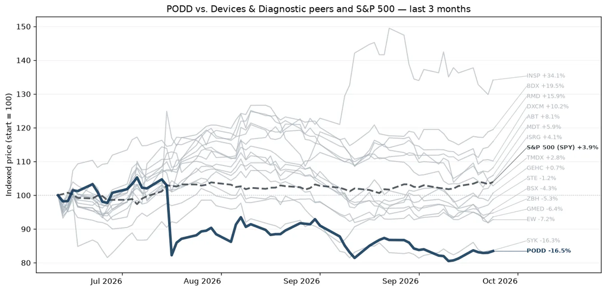

Insulet was founded in 2000 with the goal of making continuous subcutaneous insulin infusion therapy for diabetes easier to use. The result was the Omnipod system, which consists of a small disposable insulin infusion device that can be operated through a smartphone to control dosage. Since the Omnipod was approved by the US Food and Drug Administration in 2005, more than 600,000 insulin-dependent diabetic patients are using it worldwide.

### Globus Medical (GMED)

*Devices & Diagnostic · $11.1B · 3m -4.4% · 12m +32.0% · 24m +5.8%*

[Google Finance](https://www.google.com/finance/quote/GMED:NYSE?tab=earnings&hl=en)

Musculoskeletal device company focused on spine surgery, orthopedic trauma, and robotic navigation techniques.

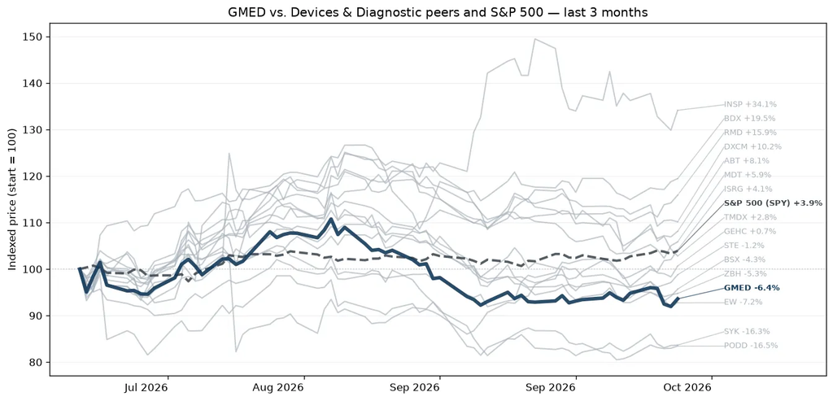

Globus Medical Inc is a medical device company that develops and provides healthcare products and solutions to hospitals, physicians, and surgical centers. The firm's products are organized into two categories: musculoskeletal solutions, which include medical devices and instruments used mostly for spinal and orthopedic procedures, and enabling technologies, which include computer systems developed for enhancing surgical capabilities. The vast majority of the company's revenue is generated from musculoskeletal solutions products, and more than half of the revenue is earned in the United States. It also has its presence internationally.

### Intuitive Surgical (ISRG)

*Devices & Diagnostic · $130.1B · 3m +4.2% · 12m -1.3% · 24m -12.5%*

[Google Finance](https://www.google.com/finance/quote/ISRG:NASDAQ?tab=earnings&hl=en)

Dominant robotic surgery company whose da Vinci systems have come the standard platform for many minimally invasive surgeries.

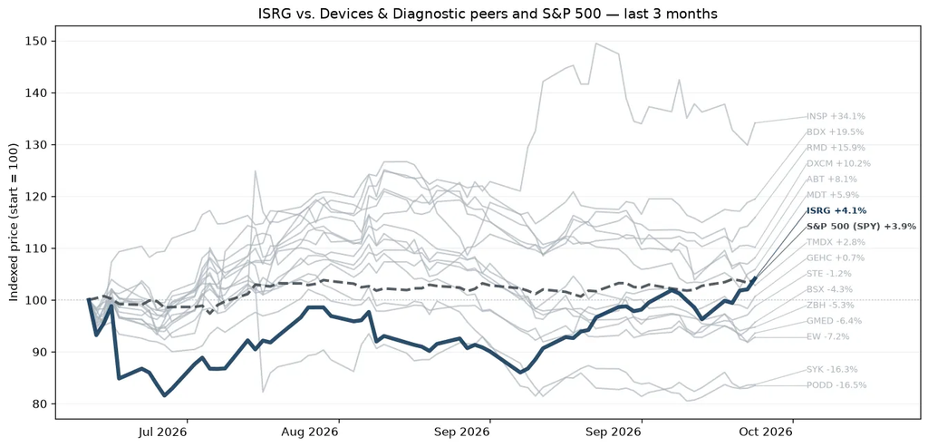

Intuitive develops, produces, and markets a robotic system for assisting minimally invasive surgery. It also provides the instrumentation, disposable accessories, and warranty services for the system. The company has placed more than 10,000 da Vinci systems in hospitals worldwide, with more than 6,000 installations in the US and a growing number in emerging markets.

### GE Healthcare (GEHC)

*Devices & Diagnostic · $31.7B · 3m +1.6% · 12m -7.4% · 24m -27.8%*

[Google Finance](https://www.google.com/finance/quote/GEHC:NASDAQ?tab=earnings&hl=en)

Medical technology & diagnostic company focused on imaging equipment, patient monitoring, ultrasound, and healthcare IT infrastructure.

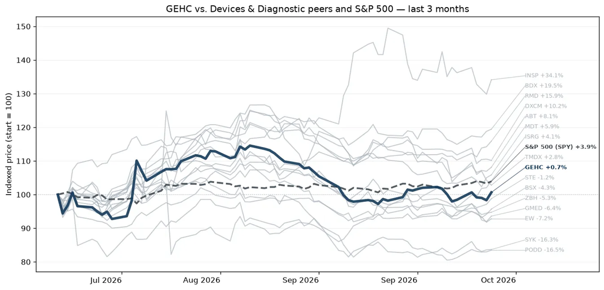

GE HealthCare Technologies is a leading medical technology firm with leading market share in imaging and ultrasound equipment. The company reports four major segments: imaging (45% of revenue), advanced visualization solutions (26%), patient care solutions (15%), and pharmaceutical diagnostics (14%). The company's sales are geographically diverse, with the United States, EMEA, China, and the rest of the world accounting for 46%, 26%, 11%, and 17%, respectively. We estimate approximately half of its revenue is recurring, which consists of servicing (about one-third of revenue), pharmaceutical diagnostics (about 10%-15%), and digital solutions (just over 5%).

### Transmedics (TMDX)

*Devices & Diagnostic · $2.8B · 3m +9.3% · 12m -27.4% · 24m -42.4%*

[Google Finance](https://www.google.com/finance/quote/TMDX:NASDAQ?tab=earnings&hl=en)

Transplant technology and transportation company whose Organ Care System keeps donor organs functioning outside the body, expanding organ supply.

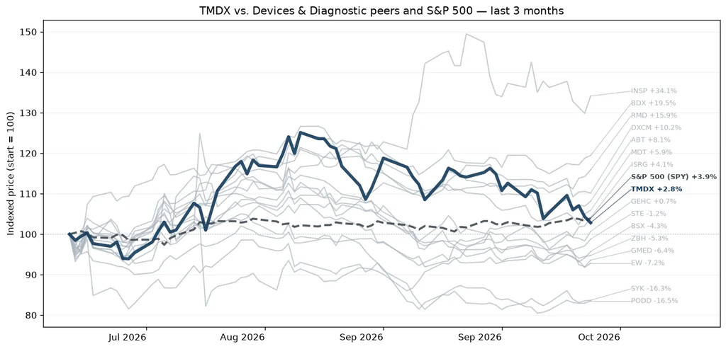

TransMedics Group Inc is a commercial-stage medical technology company transforming organ transplant therapy for end-stage organ failure patients across multiple disease states. It has developed the Organ Care System (OCS) to comprehensively address the limitations of cold storage. The OCS is a portable organ perfusion, optimization, and monitoring system that utilizes technology to replicate near-physiologic conditions for donor organs outside of the human body. The company has developed and is commercializing a proprietary system to preserve and deliver human organs for transplant in a near-physiologic condition to address the limitations of cold storage organ preservation.

### STERIS (STE)

*Devices & Diagnostic · $22.7B · 3m -0.7% · 12m -9.1% · 24m -5.5%*

[Google Finance](https://www.google.com/finance/quote/STE:NYSE?tab=earnings&hl=en)

provider of infection prevention, sterilization, and surgical support products and services.

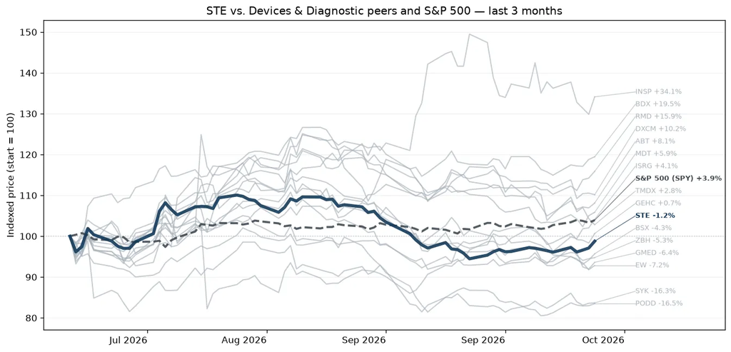

Steris is an Ireland-domiciled medical technology company focused on sterilization services and infection prevention. The company is the global leader in contract sterilization services, ensuring the safe delivery of single-use and implantable medical equipment to hospitals around the world. Steris also sells sterilizers, washer-disinfectors, and other decontamination equipment and supplies for use by care provider facilities and in biopharma manufacturing sites. Domiciled in the United States before its inversion to Ireland, the firm derives approximately 70% of its revenue from Healthcare Services, 20% from Applied Sterilization Technologies, or AST, and 10% from life sciences services after the divestment of its dental products business.

### Inspire Medical Systems (INSP)

*Devices & Diagnostic · $1.9B · 3m +33.1% · 12m -8.4% · 24m -67.3%*

[Google Finance](https://www.google.com/finance/quote/INSP:NYSE?tab=earnings&hl=en)

developer of implantable neurostimulation devices for obstructive sleep apnea.

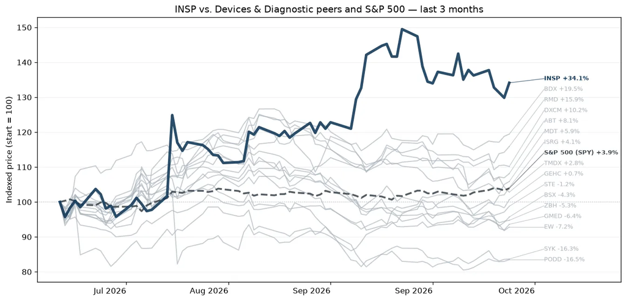

Inspire Medical Systems Inc operates as a medical technology company. It focuses on the development and commercialization of minimally invasive solutions for patients with obstructive sleep apnea (OSA). It offers Inspire system, a neurostimulation technology that provides a safe and effective treatment for moderate to severe obstructive sleep apnea. The firm has operating footprints in the United States and All other countries wherein, it generates a majority of its revenue from the United States. Its segment revenues are derived from the sales of its product, the Inspire system, to hospitals and ambulatory surgery centers in the U.S. and in selected countries in Europe and the Asia Pacific region.

### Eli Lilly (LLY)

*Big Pharma · $1.0T · 3m -0.8% · 12m +41.5% · 24m +26.5%*

[Google Finance](https://www.google.com/finance/quote/LLY:NYSE?tab=earnings&hl=en)

Obesity and diabetes powerhouse with GLP-1 franchise (Zepbound/Mounjaro) fueling growth.

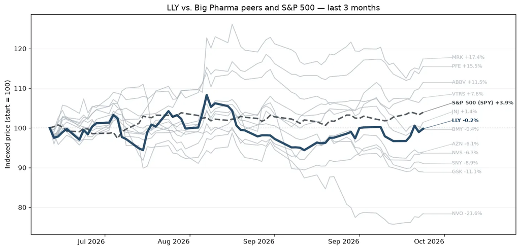

Eli Lilly is a drug firm with a focus on neuroscience, cardiometabolic, cancer, and immunology. Lilly's key products include Verzenio and Jaypirca for cancer; Mounjaro, Zepbound, Foundayo, Jardiance, Trulicity, Humalog, and Humulin for cardiometabolic; and Taltz and Olumiant for immunology.

### Novo Nordisk (NVO)

*Big Pharma · $195.8B · 3m -21.9% · 12m -32.1% · 24m -67.8%*

[Google Finance](https://www.google.com/finance/quote/NVO:NYSE?tab=earnings&hl=en)

Primary GLP-1 competitor to Lilly.

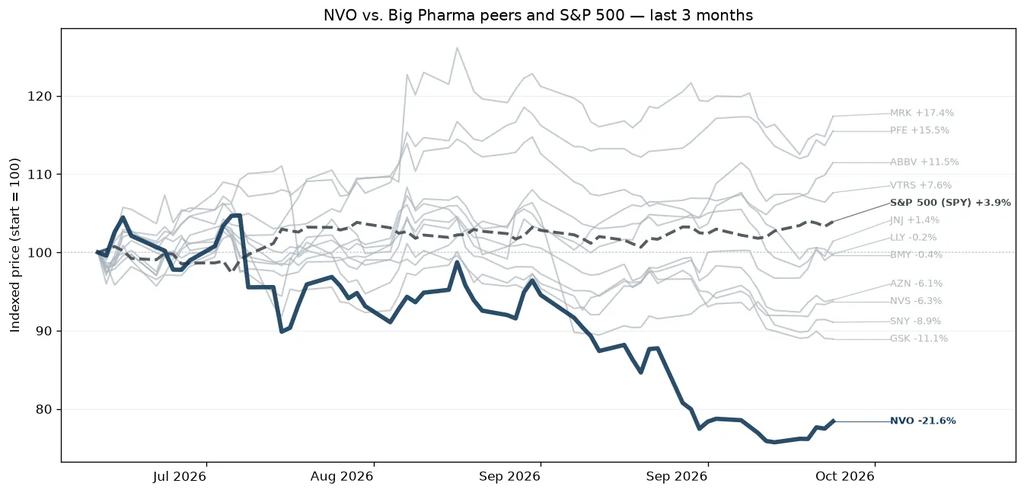

With roughly one-third of the global branded diabetes treatment market, Novo Nordisk is the leading provider of diabetes care products in the world. Based in Denmark, the company manufactures and markets a variety of human and modern insulins, injectable diabetes treatments such as GLP-1 therapy, oral antidiabetic agents, and obesity treatments. Novo also has a biopharmaceutical segment (contributing less than 10% of revenue) that specializes in protein therapies for hemophilia and other disorders.

### AbbVie (ABBV)

*Big Pharma · $430.8B · 3m +11.4% · 12m +19.9% · 24m +42.4%*

[Google Finance](https://www.google.com/finance/quote/ABBV:NYSE?tab=earnings&hl=en)

Immunology and aesthetics leader built around drugs like Skyrizi, Rinvoq, and Botox.

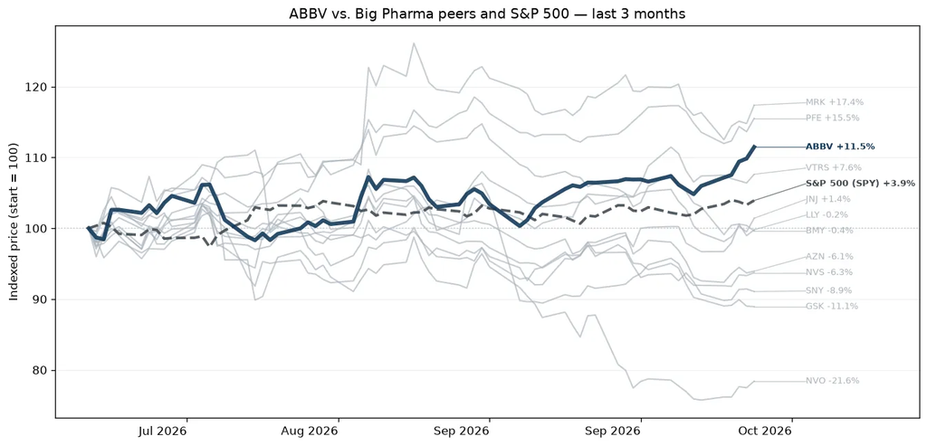

AbbVie is a pharmaceutical firm with a strong exposure to immunology (with Humira, Skyrizi, and Rinvoq) and oncology (with Imbruvica and Venclexta). The company was spun off from Abbott in early 2013. The 2020 acquisition of Allergan added several new products and drugs in aesthetics, including Botox. The 2024 acquisitions of Cerevel (neuroscience) and ImmunoGen (oncology) help supplement AbbVie's portfolio.

### Johnson & Johnson (JNJ)

*Big Pharma · $614.4B · 3m +1.7% · 12m +37.1% · 24m +61.9%*

[Google Finance](https://www.google.com/finance/quote/JNJ:NYSE?tab=earnings&hl=en)

Diversified healthcare giant, combining pharmaceuticals with medical devices.

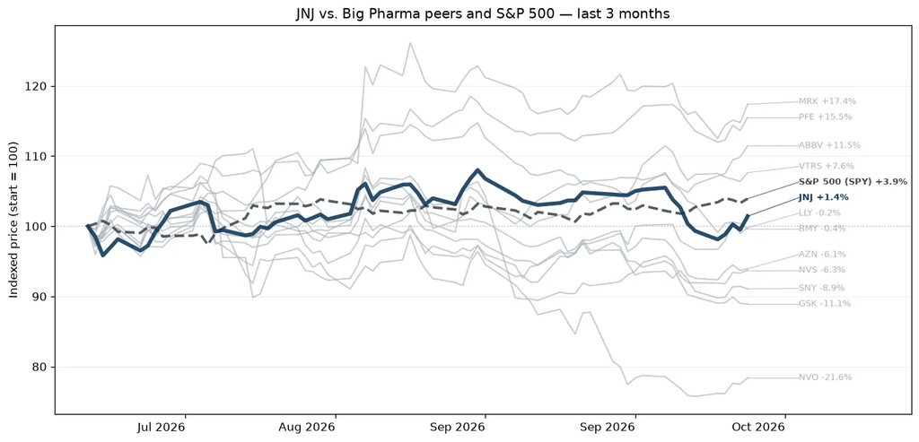

Johnson & Johnson is the world's largest and most diverse healthcare firm. It has two divisions: innovative medicine and medtech. These now represent all of the company's sales following the divestment of the consumer business, Kenvue, in 2023. After restructurings in 2023-24, the drug division focuses on three main therapeutic areas: immunology, oncology, and neurology. Geographically, just over half of total revenue is generated in the United States.

### Pfizer (PFE)

*Big Pharma · $144.8B · 3m +17.0% · 12m +14.1% · 24m -3.0%*

[Google Finance](https://www.google.com/finance/quote/PFE:NYSE?tab=earnings&hl=en)

Global pharma company known for vaccines and oncology.

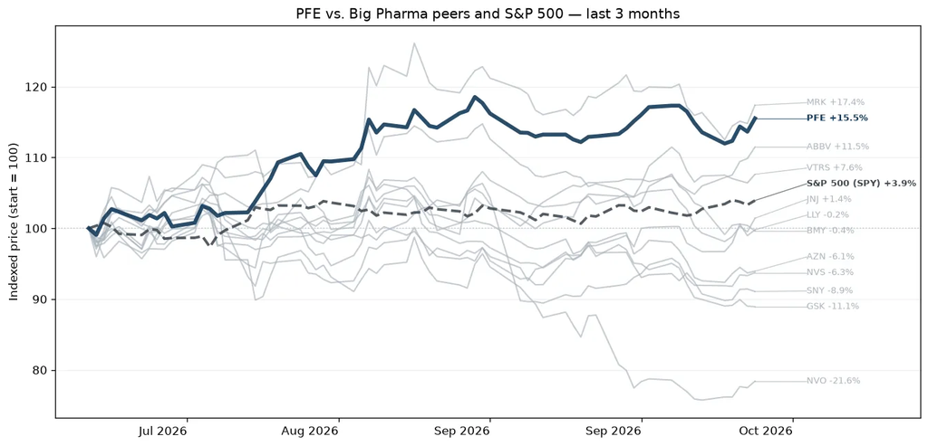

Pfizer is one of the world's largest pharmaceutical firms, with annual sales of roughly $60 billion. While it historically sold many types of healthcare products and chemicals, now prescription drugs and vaccines account for the majority of sales. Top sellers include pneumococcal vaccine Prevnar 13 and cardiology drugs Vyndaqel and Eliquis. Pfizer sells these products globally, with international sales representing 40% of total sales. Within international sales, emerging markets are a major contributor.

### Merck (MRK)

*Big Pharma · $316.1B · 3m +17.9% · 12m +69.3% · 24m +32.7%*

[Google Finance](https://www.google.com/finance/quote/MRK:NYSE?tab=earnings&hl=en)

Pharma leader driven by Keytruda, one of the world's most important cancer drugs.

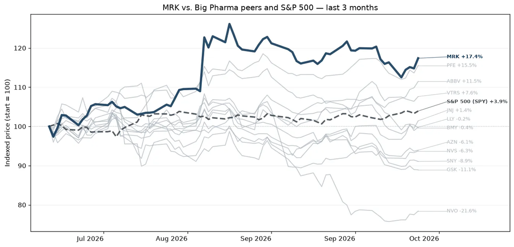

Merck makes pharmaceutical products to treat several conditions in a number of therapeutic areas, including cardiometabolic disease, cancer, and infections. Within cancer, the firm's immuno-oncology platform, led by Keytruda, is a major contributor to overall sales. The company also has a substantial vaccine business aimed at preventing pediatric diseases, as well as Gardasil for human papillomavirus. Additionally, Merck sells animal health-related drugs. From a geographical perspective, 47% of the company's sales are generated from US human health (pharmaceuticals and vaccines).

### Bristol Myers Squibb (BMY)

*Big Pharma · $134.6B · 3m +2.7% · 12m +34.5% · 24m +13.3%*

[Google Finance](https://www.google.com/finance/quote/BMY:NYSE?tab=earnings&hl=en)

Oncology and immunology specialist with a porfolio centered on cancer and cardiovascular medicines.

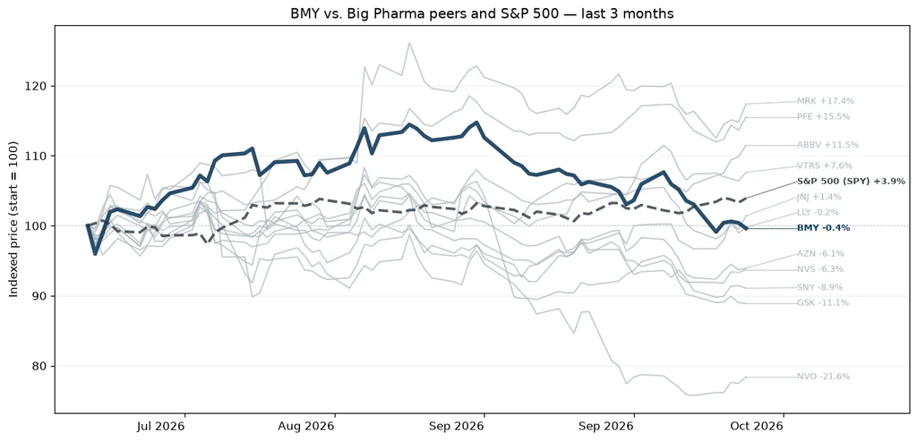

Bristol Myers Squibb discovers, develops, and markets drugs for various therapeutic areas, such as cardiovascular, cancer, and immune disorders. A key focus for Bristol is immuno-oncology, where the firm is a leader in drug development. Bristol derives close to 70% of total sales from the US, showing a higher dependence on the US market than most of its peer group.

### Viatris (VTRS)

*Big Pharma · $20.6B · 3m +8.4% · 12m +81.1% · 24m +55.0%*

[Google Finance](https://www.google.com/finance/quote/VTRS:NASDAQ?tab=earnings&hl=en)

Global generic and off-patent medicine company focused on scale manufacturing and cash generation, rather than breakthrough innovation.

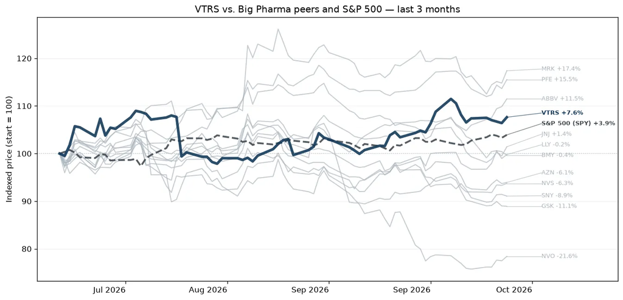

Viatris was formed in November 2020 through the combination of Upjohn, a wholly owned subsidiary of Pfizer that specialized in off-patent drugs, and Mylan, a global pharmaceutical manufacturer that focused on generic and specialty drugs. By joining forces, Viatris became one of the largest generic drug manufacturers in the world, servicing over 165 countries. Generics (commoditized and complex) and biosimilars make up roughly 40% of Viatris' total sales. The remaining 60% of sales are derived from its portfolio of legacy products, which includes Lipitor, Norvasc, Lyrica, and Viagra. While it covers more than 10 major therapeutic areas, Viatris has identified dermatology, ophthalmology, and gastroenterology as its three key areas of focus for future innovations.

### AstraZeneca (AZN)

*Big Pharma · $241.3B · 3m -7.2% · 12m -5.8% · 24m +2.9%*

[Google Finance](https://www.google.com/finance/quote/AZN:NYSE?tab=earnings&hl=en)

global pharmaceutical company with leading oncology, cardiovascular, and rare disease franchises.

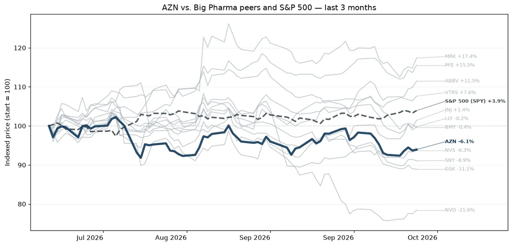

A merger between Astra of Sweden and Zeneca of the United Kingdom formed AstraZeneca in 1999. The firm sells branded drugs across a number of major therapeutic areas, including oncology (over 40% of total revenue), cardiovascular, renal, and metabolic (over 20%), rare disease (16%), and respiratory and immunology (15%). The majority of sales comes from international markets, with the United States representing close to one-third of its sales.

### Novartis (NVS)

*Big Pharma · $291.3B · 3m -6.7% · 12m +10.6% · 24m +23.7%*

[Google Finance](https://www.google.com/finance/quote/NVS:NYSE?tab=earnings&hl=en)

innovative pharmaceutical company focused on cardiovascular, immunology, neuroscience, and oncology therapies.

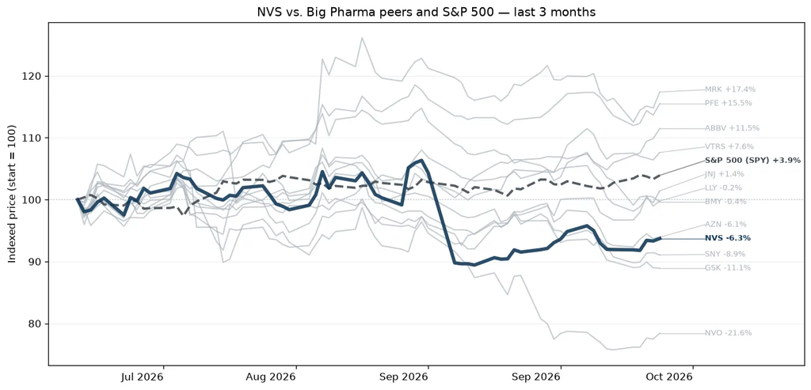

Novartis develops and manufactures innovative drugs. Key areas of drug development are oncology, immunology, neuroscience, respiratory, and cardiovascular, renal, and metabolic. It also has an established medicines business, which includes off-patent franchises. The company sells its products globally, with the United States constituting close to one-third of total revenue.

### Sanofi (SNY)

*Big Pharma · $103.6B · 3m -7.9% · 12m -16.7% · 24m -27.1%*

[Google Finance](https://www.google.com/finance/quote/SNY:NASDAQ?tab=earnings&hl=en)

diversified pharmaceutical company with strengths in vaccines, immunology, and rare diseases.

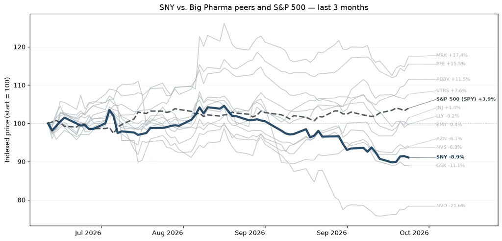

Sanofi develops and markets drugs with a concentration in immunology, vaccines, and rare diseases. Although the company offers a diverse array of drugs, its highest-revenue product, Dupixent, accounts for over 30% of total sales. Profits for this immunology blockbuster drug are shared with Regeneron. About 45% of total revenue comes from the United States, 20% from Europe, and 6% from China.

### GSK (GSK)

*Big Pharma · $103.2B · 3m -11.9% · 12m +6.8% · 24m +19.8%*

[Google Finance](https://www.google.com/finance/quote/GSK:NYSE?tab=earnings&hl=en)

pharmaceutical and vaccine company focused on infectious disease, respiratory, oncology, and specialty medicines.

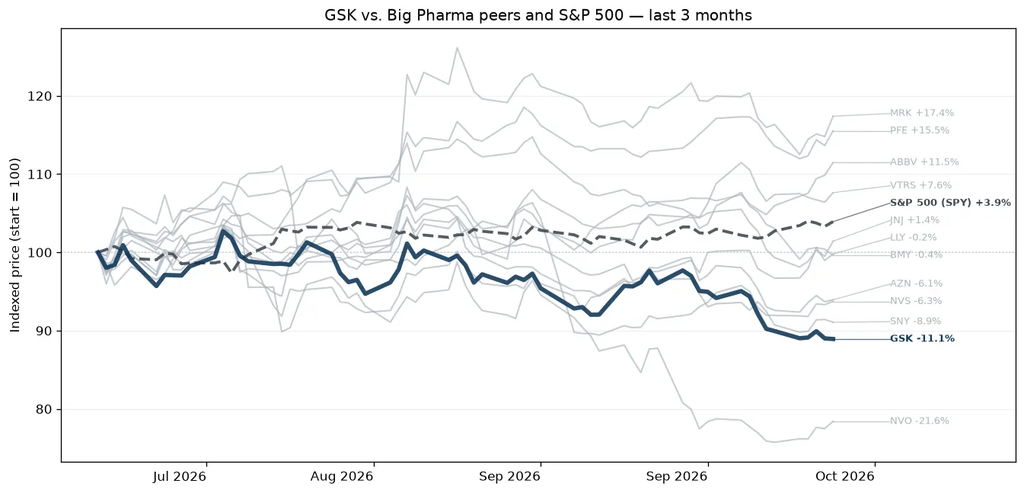

In the pharmaceutical industry, GSK ranks as one of the largest firms by total sales. The company wields its might across several therapeutic classes, including respiratory, antiviral, and vaccines, and has been growing its presence in oncology and immunology, as well. GSK uses joint ventures to gain additional scale in certain markets like HIV.

### Vertex (VRTX)

*Established Biotech · $121.3B · 3m +5.1% · 12m +25.1% · 24m +5.9%*

[Google Finance](https://www.google.com/finance/quote/VRTX:NASDAQ?tab=earnings&hl=en)

Dominant cystic fibrosis company expanding into gene editing, pain, and other specialty diseases.

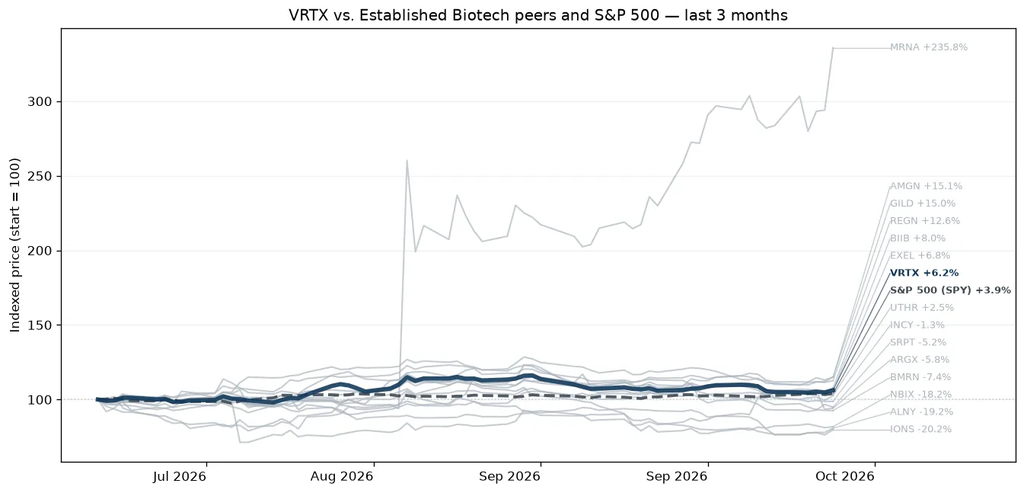

Vertex Pharmaceuticals is a global biotechnology company that discovers and develops small-molecule drugs for the treatment of serious diseases. Its key drugs are Kalydeco, Orkambi, Symdeko, and Trikafta/Kaftrio, and Alyftrek for cystic fibrosis, where Vertex therapies remain the standard of care globally. Vertex has diversified its portfolio through Casgevy, a gene-editing therapy for beta thalassemia and sickle-cell disease, and Journavx, a non-opioid pain medication approved for the treatment of moderate-to-severe acute pain in adults. Additionally, Vertex is evaluating small-molecule inhibitors of APOL1-mediated kidney diseases. Vertex is also investigating cell therapies to deliver a potential functional cure for type 1 diabetes.